# Bellabeat Case Study

#### 5.3 Check the daily average by user

```r
daily_average <- daily_activity_sleep %>%
  group_by(id) %>%
  summarise (mean_daily_steps = mean(total_steps), mean_daily_calories = mean(calories), mean_daily_sleep = mean(total_minutes_asleep))

head(daily_average)
```

```
## # A tibble: 6 × 4
##           id mean_daily_steps mean_daily_calories mean_daily_sleep
##        <dbl>            <dbl>               <dbl>            <dbl>
## 1 1503960366           12406.               1872.             360.
## 2 1644430081            7968.               2978.             294
## 3 1844505072            3477                1676.             652
## 4 1927972279            1490                2316.             417
## 5 2026352035            5619.               1541.             506.
## 6 2320127002            5079                1804               61
```

#### 5.4 Classify active type

```r
active_type <- daily_average %>%
  mutate(active_type = case_when(
    mean_daily_steps < 5000 ~ "sedentary",
    mean_daily_steps >= 5000 & mean_daily_steps < 7499 ~ "lightly active",
    mean_daily_steps >= 7500 & mean_daily_steps < 9999 ~ "fairly active",
    mean_daily_steps >= 10000 ~ "very active"
  ))

head(active_type)
```

```
## # A tibble: 6 × 5
##           id mean_daily_steps mean_daily_calories mean_daily_sleep active_type
##        <dbl>            <dbl>               <dbl>            <dbl> <chr>
## 1 1503960366           12406.               1872.             360. very active
## 2 1644430081            7968.               2978.             294  fairly active
## 3 1844505072            3477                1676.             652  sedentary
## 4 1927972279            1490                2316.             417  sedentary
## 5 2026352035            5619.               1541.             506. lightly acti…
## 6 2320127002            5079                1804               61  lightly acti…
```

#### 5.5 The proportion of each type

```r
user_type_sum <- active_type %>%
  group_by(active_type) %>%
  summarise(total= n()) %>%
  mutate(total_percent= scales::percent (total/sum(total))) %>%
  arrange(match(active_type, c("very active", "fairly active", "lightly active", "sedentary")))
  ## use arrange(match()) to order the way you want

head(user_type_sum)
```

```
## # A tibble: 4 × 3
##   active_type    total total_percent
##   <chr>          <int> <chr>
## 1 very active        5 21%
## 2 fairly active      9 38%
## 3 lightly active     5 21%
## 4 sedentary          5 21%
```

#### 5.6 Usage of smart device

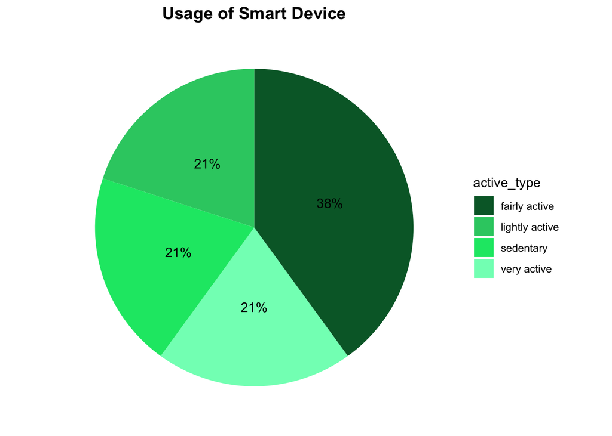

```r
custom_colors <- c("#006633","#2ECC71", "#00e673", "#80ffbf")

ggplot(user_type_sum, aes(x=" ", y=total_percent, fill=active_type)) +
  geom_bar(stat="identity", width=1) +
  coord_polar(theta="y") +
  theme_minimal() +
  theme(axis.title.x= element_blank(),
        axis.title.y = element_blank(),
        panel.border = element_blank(),
        panel.grid = element_blank(),
        axis.ticks = element_blank(),
        axis.text.x = element_blank(),
        plot.title = element_text(hjust = 0.5, size=14, face = "bold")) +
  geom_text(aes(label = total_percent),
            position = position_stack(vjust = 0.5)) +
  ggtitle("Usage of Smart Device") +
  scale_fill_manual(values = custom_colors)
```

#### 5.7 Hourly steps throughout the day

```r
hourly_steps <- hourly_steps %>%
  separate(date_time, into = c("date", "time"), sep= " ") %>%
  mutate(date = ymd(date)) %>%
  group_by(time) %>%
  summarize(average_steps = mean(step_total))
head(hourly_steps)
```

```
## # A tibble: 6 × 2
##   time     average_steps
##   <chr>            <dbl>
## 1 01:00:00         23.1
## 2 02:00:00         17.1
## 3 03:00:00          6.43
## 4 04:00:00         12.7
## 5 05:00:00         43.9
## 6 06:00:00        179.
```

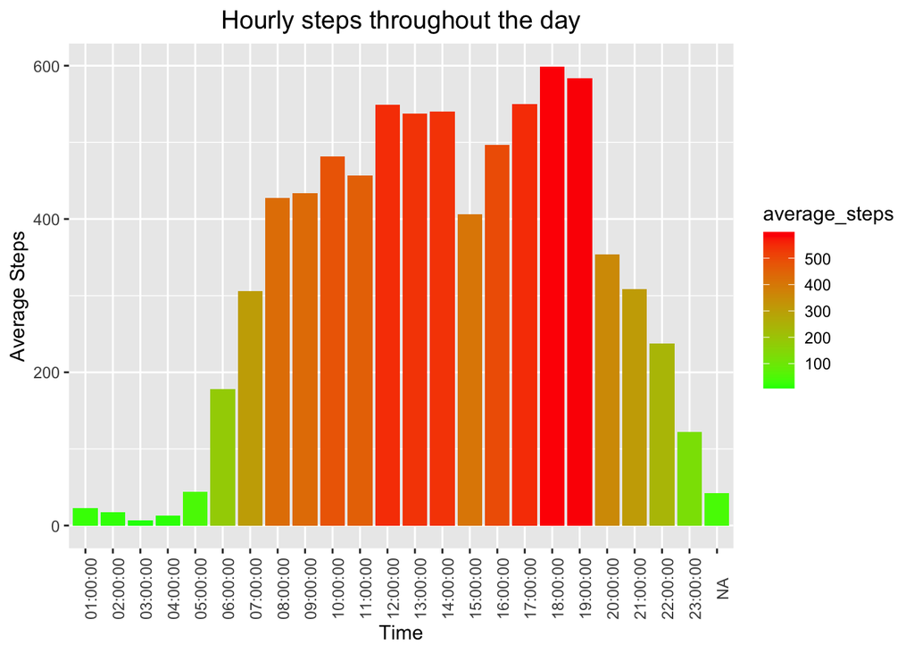

```r
ggplot(hourly_steps, aes(x=time, y = average_steps, fill = average_steps)) +
  geom_col()  +
  labs(title = "Hourly steps throughout the day", x="Time", y="Average Steps") +
  scale_fill_gradient(low = "green", high = "red")+
  theme(axis.text.x = element_text(angle = 90), plot.title = element_text(size=14, hjust=0.5))
```

As shown in the plot, we can see that users are more active during lunch time from 12pm to 2pm and evenings from 5pm and 7pm.

## 6. Conclusion

1. There is no correlation between Daily Steps and Minutes Asleep.
2. There is a positive correlation between Daily Steps and Calories Burned, meaning that the more steps taken, the more calories one may burn.
3. 42% of the users (10 users) didn’t reach at least daily recommended steps by CDC, wich is 7,500 steps.
4. Users are more active during lunch time from 12pm to 2pm and evenings from 5pm and 7pm.

Recommendations:

1. The application could provide valuable insights into the health benefits of walk exceeding 7,500 steps each day, enhancing users’ understanding of the positive impact on their well-being. Aiding users in setting personalized goals according to their profiles, lifestyles, and health conditions. The intensity can gradually increase on a monthly basis. Additionally, the app sends reminders to users when they fall short of their goals.
2. The app introduces a reward system to motivate users to achieve their goals.
3. While there may be no direct correlation between daily step counts and minutes of sleep, inadequate sleep can impact users’ health and indirectly influence their daily step count. The app can also send sleep reminders to users.
4. Given that the majority of our users are white-collar workers, a reasonable hourly step goal during midday from 12 pm to 2 pm and in the evenings from 5 pm to 7 pm has been set.
5. Since we encourage users to wear our product throughout the day for comprehensive data collection, long-lasting battery life is crucial. Additionally, water resistance and stylish, elegant designs are important features for our product.